# Price Elasticity

Wei Xie

10/24/2018

# Introduction

In this study, we follow the ideas in a recent [blog on price elasticity modeling](https://towardsdatascience.com/calculating-price-elasticity-of-demand-statistical-modeling-with-python-6adb2fa7824d). We will use R to build a regression model to estimate the price elasticity.

# Data Analysis

## Data Preparation

```r
library(tidyverse)
library(gridExtra)
library(lubridate)
library(broom)
```

The data set of this analysis can be downloaded from [here](https://raw.githubusercontent.com/susanli2016/Machine-Learning-with-Python/master/beef.csv).

```r
df <- read_csv("beef.csv")
df
```

```
## # A tibble: 91 x 4
##     Year Quarter Quantity Price
##    <int>   <int>    <dbl> <dbl>
##  1  1977       1     23.0  142.
##  2  1977       2     22.6  144.
##  3  1977       3     23.4  146.
##  4  1977       4     22.7  151.
##  5  1978       1     22.0  160
##  6  1978       2     21.8  183.
##  7  1978       3     21.6  186.
##  8  1978       4     21.9  186.
##  9  1979       1     20.5  212.
## 10  1979       2     19.0  232.
## # ... with 81 more rows
```

The data set is the quarterly beef sale and price from 1Q1977 to 3Q1999. Therefore, let’s visualize the trend.

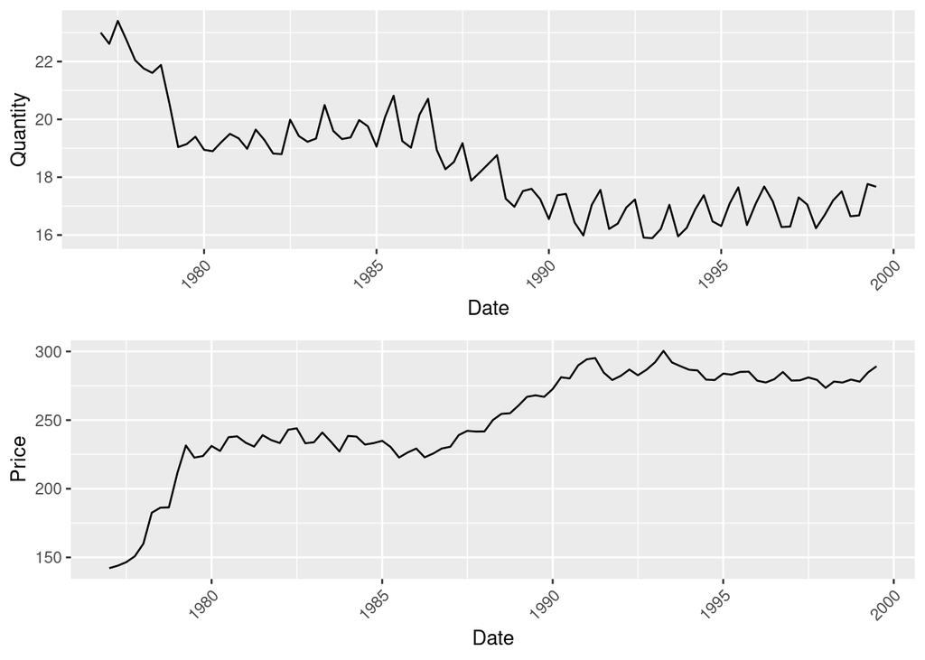

```r
df %>%
  mutate(date=make_date(Year, (Quarter-1)*3+1, 1)) %>%
  ggplot(aes(x=date, y=Quantity)) +
  geom_line() +
  labs(x="Date",y="Quantity") +
  theme(axis.text.x=element_text(angle=45,hjust=1)) -> p1

df %>%
  mutate(date=make_date(Year, (Quarter-1)*3+1, 1)) %>%
  ggplot(aes(x=date, y=Price)) +
  geom_line() +
  labs(x="Date",y="Price") +
  theme(axis.text.x=element_text(angle=45,hjust=1)) -> p2

grid.arrange(p1,p2,ncol=1)
```

We can see that the price and quantity do change in opposite directions. For example, quantity sharply decreased from 1977 to 1980 as price increased rapidly in the same time.

## Analysis

Based on definition of economics, the elasticity is

$$elasticity = \frac{\partial\log(d)}{\partial\log(P)}$$

where $d$ is the demand and $P$ is the price. Therefore, we will produce a linear regression model on $\log(d)$ vs. $\log(P)$.

```r
elast_lm <- lm(log(Quantity) ~ log(Price), data=df)
summary(elast_lm)
```

```
##
## Call:
## lm(formula = log(Quantity) ~ log(Price), data = df)
##
## Residuals:
##       Min        1Q    Median        3Q       Max
## -0.077011 -0.034805  0.002406  0.025817  0.083739
##
## Coefficients:
##             Estimate Std. Error t value Pr(>|t|)
## (Intercept)  5.83637    0.12941   45.10   <2e-16 ***
## log(Price)  -0.53142    0.02347  -22.64   <2e-16 ***
## ---
## Signif. codes:  0 '***' 0.001 '**' 0.01 '*' 0.05 '.' 0.1 ' ' 1
##
## Residual standard error: 0.0371 on 89 degrees of freedom
## Multiple R-squared:  0.8521, Adjusted R-squared:  0.8504
## F-statistic: 512.6 on 1 and 89 DF,  p-value: < 2.2e-16
```

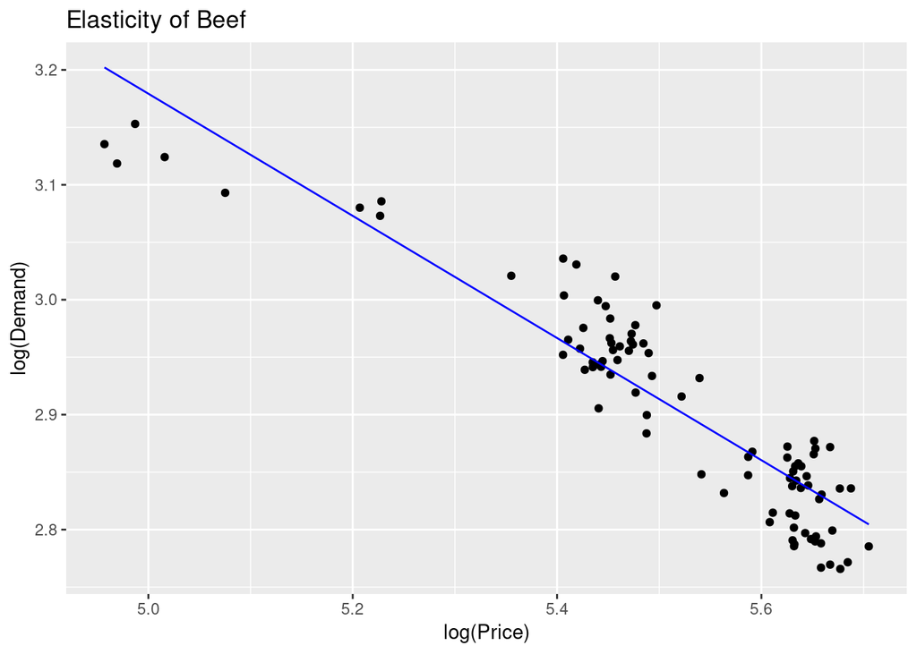

```r
elast_val <- unlist(tidy(elast_lm)["2","estimate"])

elast_lm %>% augment() %>%
  ggplot(aes(x=log.Price.)) +
  geom_point(aes(y=log.Quantity.), color="black") +
  geom_line(aes(y=.fitted), color="blue") +
  labs(x="log(Price)", y="log(Demand)") +
  guides(color=guide_legend(title="Key")) +
  ggtitle("Elasticity of Beef")
```

```r
paste("Elasticity = ", round(elast_val, digits=3))
```

```
## [1] "Elasticity =  -0.531"
```

The regression model return very good $R^2$ and the elasticity is -0.531. Let’s also review the residual graph to ensure the quality.

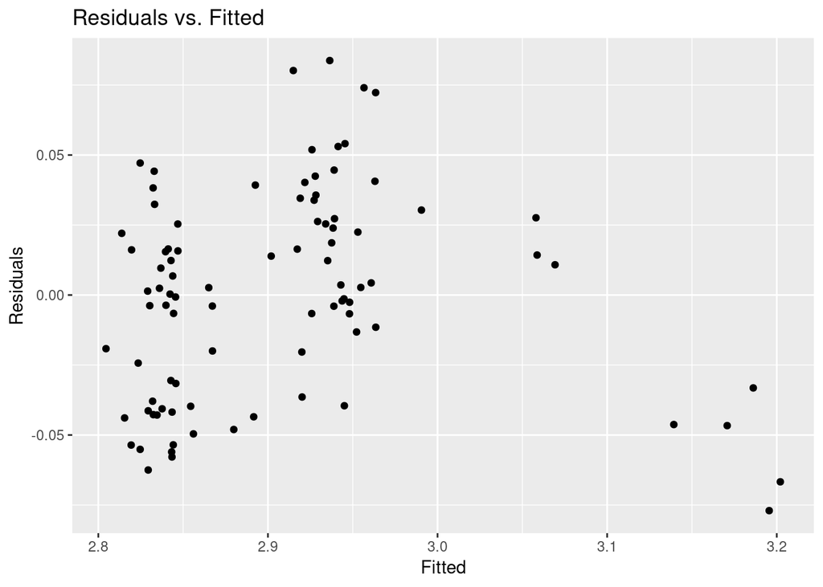

```r
elast_lm %>% augment() %>%
  ggplot(aes(x=.fitted, y=.resid)) +
  geom_point() +
  labs(x="Fitted", y="Residuals") +
  ggtitle("Residuals vs. Fitted")
```

Overall, the points seem to distribute randomally, although there is clearly some inbalance between fitted value below and above 3.

# Conclusions

Overall, the beef’s demand is fairly inelastic with regard to price as demand decreases more slowly than price. This could be that beef is a major source of protein intake for the region and it is relatively difficult to substitute it with another food.